# Define quality threshold

```r
library(DBI)
library(RMySQL)
library(tidyverse)
library(rlist)
con <- DBI::dbConnect(RMySQL::MySQL(),
                      host = "localhost",
                      user = "root",
                      dbname = "cagablea",
                      password = "")
```

## A list of all the requests calling samples:

The function below generates a list with the requests to download the samples Treshholds is a variable, where the cutoff on coverage, p.val, alt_freq and others can be added:

```r
samples <- function(treshholds){
  samples <- list()
  req <- "SELECT * FROM `ww_ivar`,`ww_barcode_decode` WHERE ww_barcode_decode.barcode = ww_ivar.filename"
  samples$oct <- "AND ww_ivar.filename LIKE BINARY '%210224%'"
  samples$nov <- "AND ww_ivar.filename LIKE BINARY '%20201120%'"
  samples$dec <- "AND ww_ivar.filename LIKE BINARY '%20201223%'"
  samples$jan <- "AND ww_ivar.filename LIKE BINARY '%210127%'"
  samples$fev <- "AND ww_ivar.filename LIKE BINARY '%20210302%'"
  samples$mar <-  "AND ww_ivar.filename LIKE BINARY '%210325%'"
  samples <- lapply(samples, function(x) paste(req, treshholds, x, " "))
  return(samples)
}
treshholds <- "AND ww_ivar.total_dp > 10 AND ww_ivar.pval < 0.05 AND ww_ivar.alt_freq > 0.03"
samples1 <- samples(treshholds)
```

Count mutations not associated to any lineage and the mutations described for at least one lineage: TRUE correspons to the mutations that are not described for any lineages

```r
no_lineage <- function(d_request){
  feb <- dbGetQuery(con, d_request)
  feb <- feb[,-1]
  feb <- distinct(feb, pos, alt, .keep_all = F)
  #how many mutations are not associated with any lineage?
  pango <- dbGetQuery(con, "SELECT * FROM `pango_lineages`")
  all.mut.id <-  feb %>% left_join(pango, by = c("pos"="pos", "alt"="alt"), keep = T )
  all.mut.id <- all.mut.id %>% select(pos.x, ref, alt.x, lineage )%>% distinct(pos.x, alt.x, ref, .keep_all = T)
  #all.mut.id
  all.mut.id %>% count(is.na(lineage))

}
#no_lineage(samples1$mar)#test
#Positions with nonsynonymous mutations in spike region not associated with lineages (top 2000 from covidcg)
  #lin_na %>% filter (ref_aa != alt_aa) %>% filter(pos.x >= 21563) %>% filter(pos.x <= 25384)
n_mut <- function(samples){
  n_id_mutations <- lapply(samples, no_lineage)
  #n_id_mutations #the number of id and unidentified mut, min number of reads 10
  n_mut <- cbind(n_id_mutations$oct, n_id_mutations$nov$n, n_id_mutations$dec$n, n_id_mutations$jan$n, n_id_mutations$fev$n, n_id_mutations$mar$n)
  names(n_mut) <- c("lin_not_id", "oct", "nov", "dec", "jan", "fev", "mar")
  n_mut
}
```

total_dp > 10 AND ww_ivar.pval < 0.05 AND ww_ivar.alt_freq > 0.03

```r
treshholds <- "AND ww_ivar.total_dp > 10 AND ww_ivar.pval < 0.05 AND ww_ivar.alt_freq > 0.03"
samples1 <- samples(treshholds)
n_mut(samples1)
```

|  | lin_not_id | oct | nov | dec | jan | fev | mar |
| --- | --- | --- | --- | --- | --- | --- | --- |
| 1 | FALSE | 152 | 192 | 229 | 280 | 229 | 235 |
| 2 | TRUE | 5947 | 15187 | 20229 | 8132 | 6822 | 7576 |

Minimum number of reads 100, alt_freq 0.1, pval<0.01:

```r
treshholds <- "AND ww_ivar.total_dp > 100 AND ww_ivar.pval < 0.01 AND ww_ivar.alt_freq > 0.1"
samples1 <- samples(treshholds)
n_mut(samples1)
```

|  | lin_not_id | oct | nov | dec | jan | fev | mar |
| --- | --- | --- | --- | --- | --- | --- | --- |
| 1 | FALSE | 88 | 84 | 98 | 160 | 115 | 137 |
| 2 | TRUE | 756 | 1277 | 1925 | 981 | 856 | 1145 |

Minimum number of reads 100, alt_freq 0.3, pval<0.01:

```r
treshholds <- "AND ww_ivar.total_dp > 100 AND ww_ivar.pval < 0.01 AND ww_ivar.alt_freq > 0.3"
samples1 <- samples(treshholds)
n_mut(samples1)
```

|  | lin_not_id | oct | nov | dec | jan | fev | mar |
| --- | --- | --- | --- | --- | --- | --- | --- |
| 1 | FALSE | 61 | 51 | 68 | 104 | 46 | 76 |
| 2 | TRUE | 88 | 61 | 88 | 135 | 58 | 159 |

```r
treshholds <- "AND ww_ivar.total_dp > 100 AND ww_ivar.pval < 0.01 AND ww_ivar.alt_freq > 0.5"
samples1 <- samples(treshholds)
n_mut(samples1)
```

|  | lin_not_id | oct | nov | dec | jan | fev | mar |
| --- | --- | --- | --- | --- | --- | --- | --- |
| 1 | FALSE | 42 | 39 | 49 | 70 | 35 | 51 |
| 2 | TRUE | 31 | 22 | 37 | 61 | 22 | 70 |

```r
treshholds <- "AND ww_ivar.total_dp > 100 AND ww_ivar.pval < 0.01 AND ww_ivar.alt_freq > 0.7"
samples1 <- samples(treshholds)
n_mut(samples1)
```

|  | lin_not_id | oct | nov | dec | jan | fev | mar |
| --- | --- | --- | --- | --- | --- | --- | --- |
| 1 | FALSE | 26 | 31 | 43 | 33 | 30 | 39 |
| 2 | TRUE | 19 | 12 | 29 | 23 | 13 | 41 |

Loop through requests with different p-value, total_dp > 100 and alt_freq > 0.1 Create a list with the sequence of p-values to test:

```r
treshholds_p_list <- list()
q <- "AND ww_ivar.total_dp > 100 AND ww_ivar.alt_freq > 0.1 AND ww_ivar.pval < "
p_values <- c(10 %o% 10^(-3:-16))
i = 1
for (i in 1:length(p_values)){
  treshholds_p_list <- list.append(treshholds_p_list, paste(q, p_values[i]) )
  i = i +1
}
```

Create a serie of requests with different p-values for every month:

```r
samples1 <- samples(treshholds_p_list)
```

n_mut_pval has 14 dataframes, that correspond to p-values in p_values vector 1e-02 1e-03 1e-04 1e-05 1e-06 1e-07 1e-08 1e-09 1e-10 1e-11 1e-12 1e-13 1e-14 1e-15

```r
i = 1
n_mut_pval <- list()
for (i in 1:length(samples1[[1]])){
  n_mut_pval <- list.append(n_mut_pval, n_mut(lapply(samples1, `[[`, i)))
  i = i + 1
}
```

Build a function to plot the number of mutatios against log10(p-value):

```r
plot_mut_pval <- function (month){
pval_nmut <- rbind(n_mut_pval[[1]][,month], n_mut_pval[[2]][,month])

for (i in 3:length(n_mut_pval)) {
  pval_nmut <- rbind(pval_nmut, n_mut_pval[[i]][,month] )
  pval_nmut
  i = i +1
}
pval_nmut<- as.data.frame(cbind(pval_nmut, p_values))
names(pval_nmut) <- c("identified", "not_id", "p_values")
print(pval_nmut)
ggplot(pval_nmut)+
  geom_point(aes(y = identified, x = log10(p_values), col = "red"))+
  geom_point(aes(y = not_id, x = log10(p_values), col = "blue"))+
  scale_y_continuous(name="Number of mutations")+
  theme(legend.position="none")

#plot(y = pval_nmut$identified, x = log10(pval_nmut$p_values))
#plot(y = pval_nmut$not_id, x = log10(pval_nmut$p_values))
}
```

## plot the number of mutatios against log10(p-value)

plot for october:

```
##    identified not_id p_values
## 1          88    756    1e-02
## 2          88    756    1e-03
## 3          88    746    1e-04
## 4          88    731    1e-05
## 5          87    721    1e-06
## 6          87    707    1e-07
## 7          87    693    1e-08
## 8          87    681    1e-09
## 9          85    661    1e-10
## 10         85    617    1e-11
## 11         84    577    1e-12
## 12         83    519    1e-13
## 13         83    470    1e-14
## 14         82    427    1e-15
```

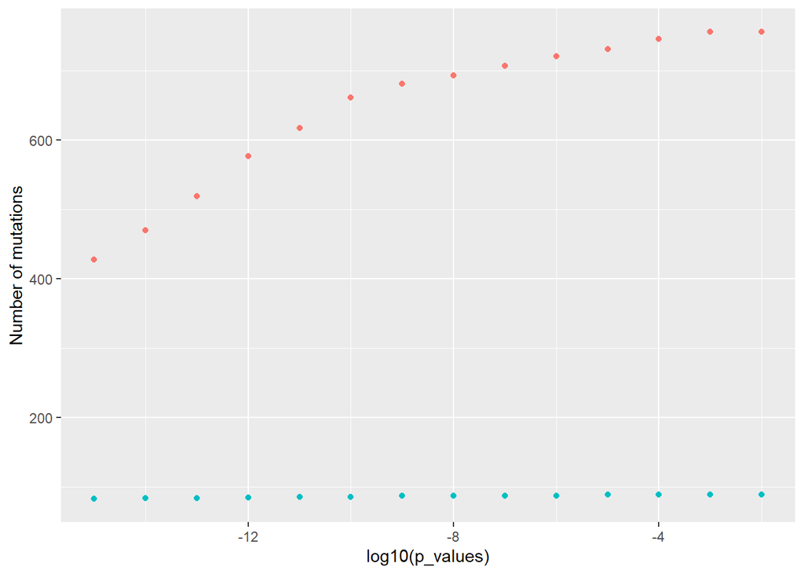

```r
month = "oct"
plot_mut_pval(month)
```

plot for november:

```
##    identified not_id p_values
## 1          84   1277    1e-02
## 2          84   1277    1e-03
## 3          84   1270    1e-04
## 4          84   1251    1e-05
## 5          82   1211    1e-06
## 6          77   1171    1e-07
## 7          74   1127    1e-08
## 8          70   1097    1e-09
## 9          68   1060    1e-10
## 10         67   1014    1e-11
## 11         67    971    1e-12
## 12         65    924    1e-13
## 13         61    876    1e-14
## 14         60    826    1e-15
```

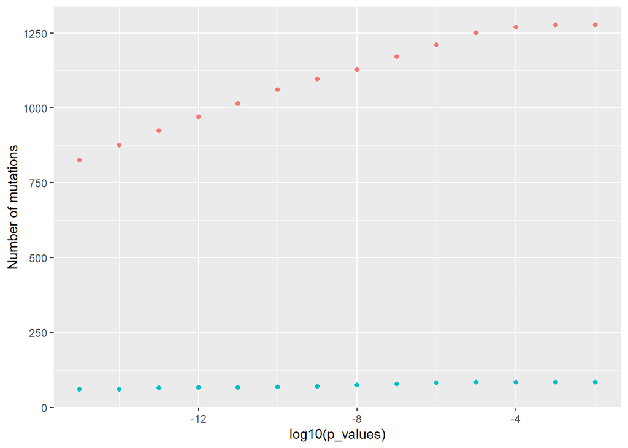

```r
month = "nov"
plot_mut_pval(month)
```

plot for december:

```
##    identified not_id p_values
## 1          98   1925    1e-02
## 2          98   1924    1e-03
## 3          98   1921    1e-04
## 4          97   1902    1e-05
## 5          95   1876    1e-06
## 6          94   1839    1e-07
## 7          93   1811    1e-08
## 8          92   1782    1e-09
## 9          90   1748    1e-10
## 10         90   1706    1e-11
## 11         87   1678    1e-12
## 12         85   1629    1e-13
## 13         84   1587    1e-14
## 14         84   1521    1e-15
```

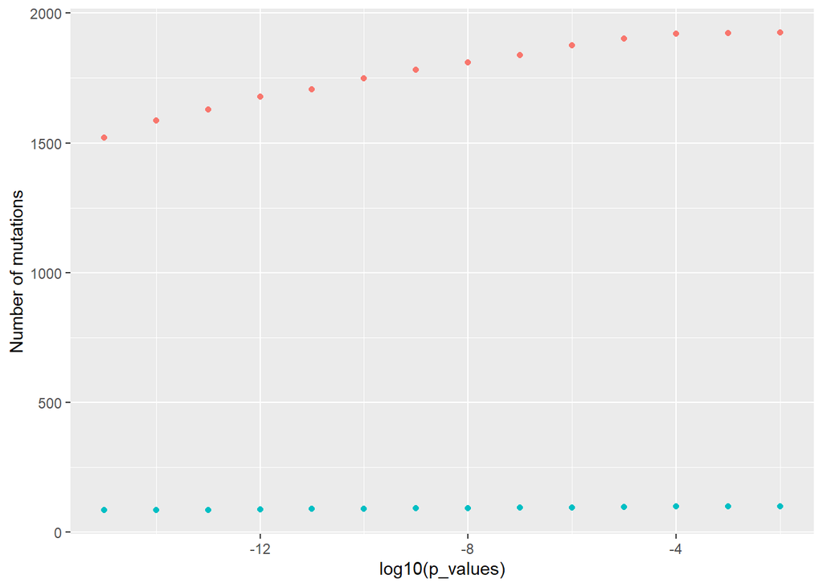

```r
month = "dec"
plot_mut_pval(month)
```

plot for january:

```
##    identified not_id p_values
## 1         160    981    1e-02
## 2         160    980    1e-03
## 3         160    966    1e-04
## 4         157    952    1e-05
## 5         157    928    1e-06
## 6         156    903    1e-07
## 7         153    874    1e-08
## 8         149    861    1e-09
## 9         146    833    1e-10
## 10        139    790    1e-11
## 11        137    752    1e-12
## 12        132    693    1e-13
## 13        130    643    1e-14
## 14        127    592    1e-15
```

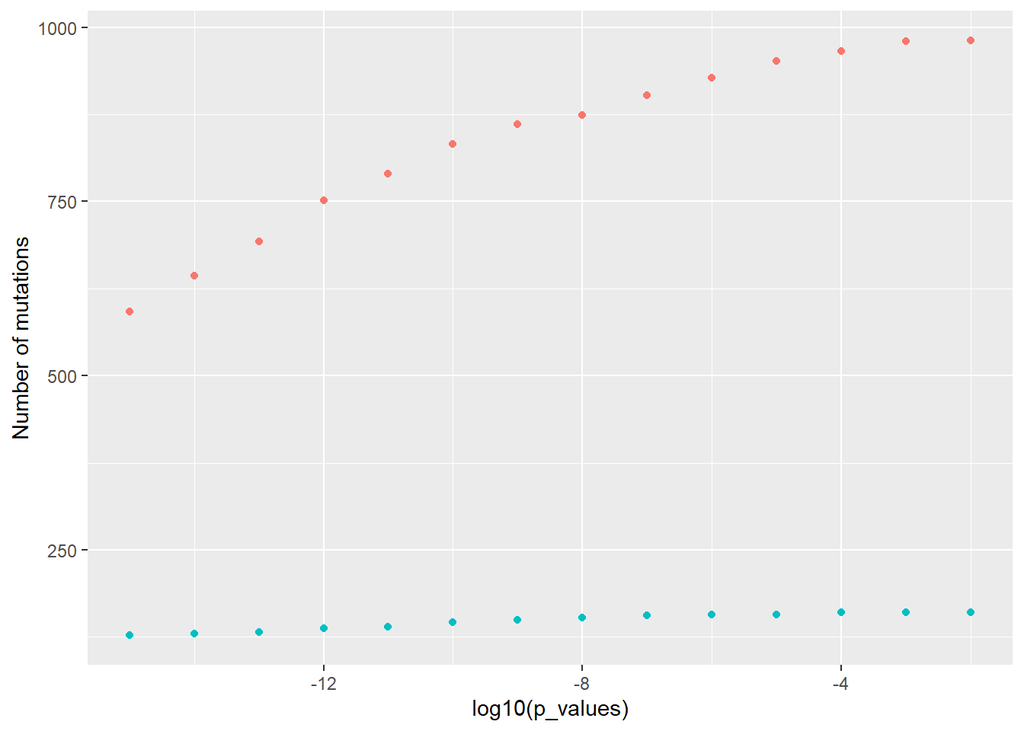

```r
month = "jan"
plot_mut_pval(month)
```

plot for february:

```
##    identified not_id p_values
## 1         115    856    1e-02
## 2         115    856    1e-03
## 3         115    851    1e-04
## 4         115    838    1e-05
## 5         115    825    1e-06
## 6         113    815    1e-07
## 7         110    800    1e-08
## 8         107    787    1e-09
## 9         103    765    1e-10
## 10        100    719    1e-11
## 11         94    662    1e-12
## 12         90    617    1e-13
## 13         86    562    1e-14
## 14         82    505    1e-15
```

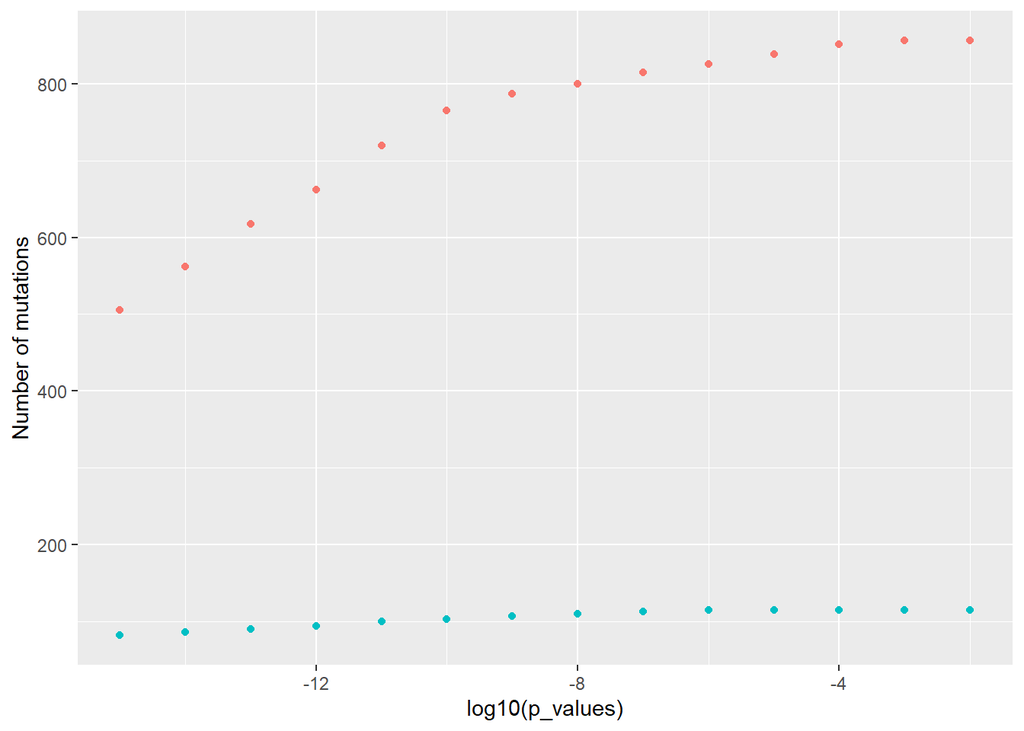

```r
month = "fev"
plot_mut_pval(month)
```

plot for march:

```
##    identified not_id p_values
## 1         137   1145    1e-02
## 2         137   1145    1e-03
## 3         137   1141    1e-04
## 4         137   1130    1e-05
## 5         137   1121    1e-06
## 6         135   1109    1e-07
## 7         130   1084    1e-08
## 8         124   1059    1e-09
## 9         122   1024    1e-10
## 10        119    971    1e-11
## 11        118    917    1e-12
## 12        114    857    1e-13
## 13        107    796    1e-14
## 14        104    715    1e-15
```

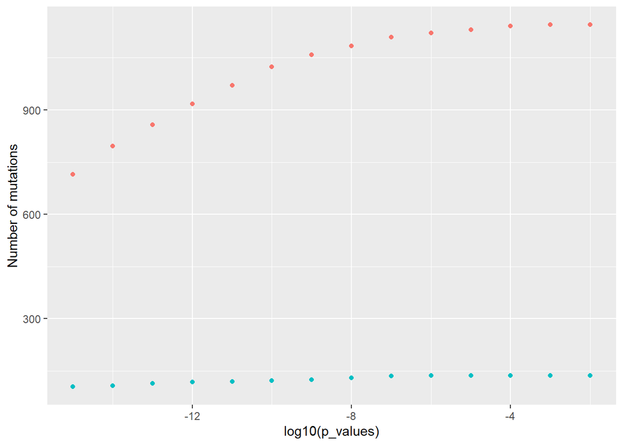

```r
month = "mar"
plot_mut_pval(month)
```

## Frequency values

Fix p-value 0.01, total_dp > 100. Create a serie of requests with alt_freq:

```r
treshholds_fr_list <- list()
q <- "AND ww_ivar.total_dp > 100  AND ww_ivar.pval < 0.01 AND ww_ivar.alt_freq > "
fr_values <- seq(0.03, 0.5, by = 0.025 )
i = 1
for (i in 1:length(fr_values)){
  treshholds_fr_list <- list.append(treshholds_fr_list, paste(q, fr_values[i]) )
  i = i +1
}
```

Create a serie of requests with different frequency values for every month:

```r
samples2 <- samples(treshholds_fr_list)
#samples2
```

```r
i = 1
n_mut_frval <- list()
for (i in 1:length(samples2[[1]])){
  n_mut_frval <- list.append(n_mut_frval, n_mut(lapply(samples2, `[[`, i)))
  i = i + 1
}
```

Build a function to plot the number of mutatios against frequecies:

```r
plot_mut_freq <- function (month){
nmut <- rbind(n_mut_frval[[1]][,month], n_mut_frval[[2]][,month])

for (i in 3:length(n_mut_frval)) {
  nmut <- rbind(nmut, n_mut_frval[[i]][,month] )
  nmut
  i = i +1
}
nmut<- as.data.frame(cbind(nmut, fr_values))
names(nmut) <- c("identified", "not_id", "frequencies")
print(nmut)
ggplot(nmut)+
  geom_point(aes(y = identified, x = frequencies, col = "red"))+
  geom_point(aes(y = not_id, x = frequencies, col = "blue"))+
  scale_y_continuous(name="Number of mutations")+
  theme(legend.position="none")

#plot(y = pval_nmut$identified, x = log10(pval_nmut$p_values))
#plot(y = pval_nmut$not_id, x = log10(pval_nmut$p_values))
}
```

plot the number of mutations in october agains diff. frequencies: Red color = Not identified mut Blue color = Identified

```
##    identified not_id frequencies
## 1         122   5127       0.030
## 2         103   2094       0.055
## 3          94   1081       0.080
## 4          88    682       0.105
## 5          82    457       0.130
## 6          76    322       0.155
## 7          73    235       0.180
## 8          71    174       0.205
## 9          68    141       0.230
## 10         65    112       0.255
## 11         64     97       0.280
## 12         60     85       0.305
## 13         56     73       0.330
## 14         53     61       0.355
## 15         52     54       0.380
## 16         50     48       0.405
## 17         49     40       0.430
## 18         45     35       0.455
## 19         43     31       0.480
```

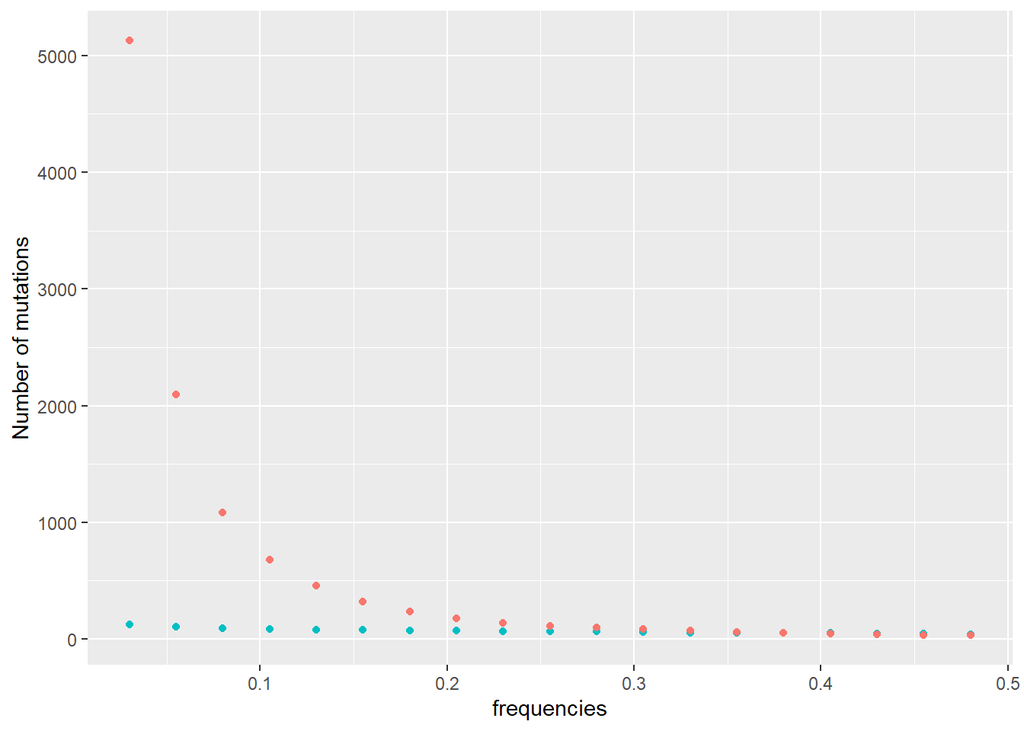

```r
plot_mut_freq(month = "oct")
```

November:

```
##    identified not_id frequencies
## 1         132  11390       0.030
## 2         117   4314       0.055
## 3          92   2053       0.080
## 4          81   1108       0.105
## 5          71    702       0.130
## 6          68    480       0.155
## 7          63    306       0.180
## 8          61    211       0.205
## 9          58    155       0.230
## 10         54    105       0.255
## 11         53     78       0.280
## 12         49     58       0.305
## 13         47     50       0.330
## 14         42     47       0.355
## 15         42     39       0.380
## 16         42     34       0.405
## 17         42     30       0.430
## 18         40     26       0.455
## 19         40     24       0.480
```

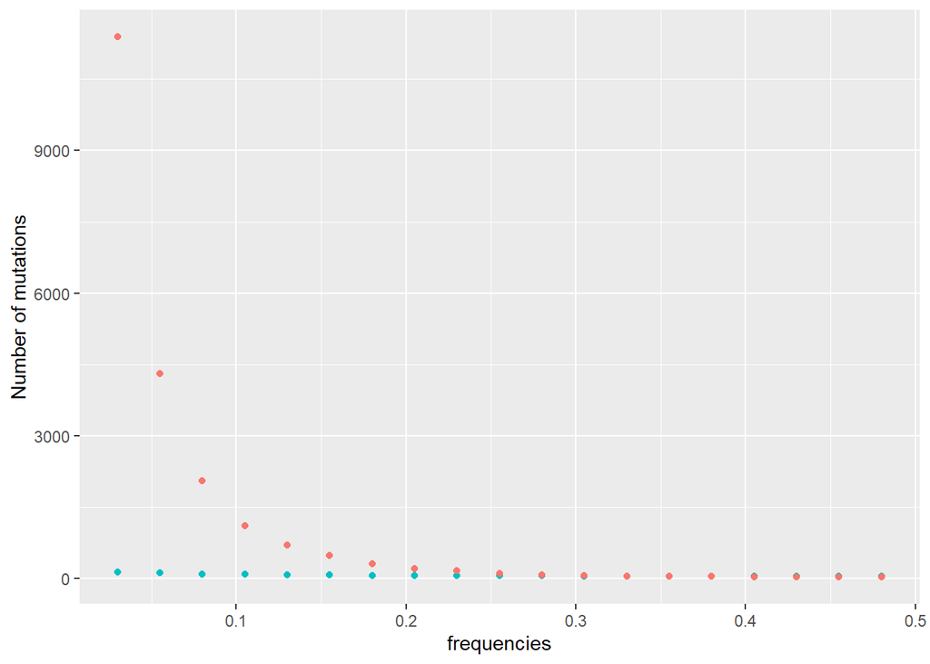

```r
plot_mut_freq(month = "nov")
```

December:

```
##    identified not_id frequencies
## 1         133  16363       0.030
## 2         119   6178       0.055
## 3         106   2977       0.080
## 4          96   1709       0.105
## 5          93   1093       0.130
## 6          88    722       0.155
## 7          84    492       0.180
## 8          80    310       0.205
## 9          76    220       0.230
## 10         70    152       0.255
## 11         69    111       0.280
## 12         67     86       0.305
## 13         66     67       0.330
## 14         66     58       0.355
## 15         62     52       0.380
## 16         59     44       0.405
## 17         58     40       0.430
## 18         55     40       0.455
## 19         51     38       0.480
```

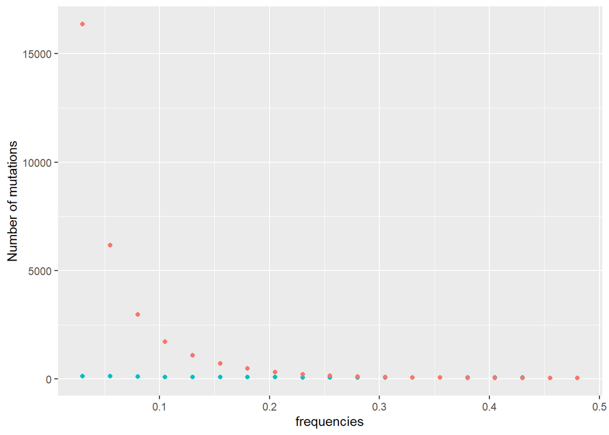

```r
plot_mut_freq(month = "dec")
```

January:

```
##    identified not_id frequencies
## 1         233   6650       0.030
## 2         202   2836       0.055
## 3         172   1473       0.080
## 4         157    894       0.105
## 5         141    591       0.130
## 6         131    432       0.155
## 7         128    317       0.180
## 8         118    253       0.205
## 9         114    208       0.230
## 10        110    169       0.255
## 11        106    148       0.280
## 12        103    133       0.305
## 13         99    117       0.330
## 14         98    107       0.355
## 15         94    101       0.380
## 16         89     95       0.405
## 17         83     85       0.430
## 18         81     78       0.455
## 19         76     67       0.480
```

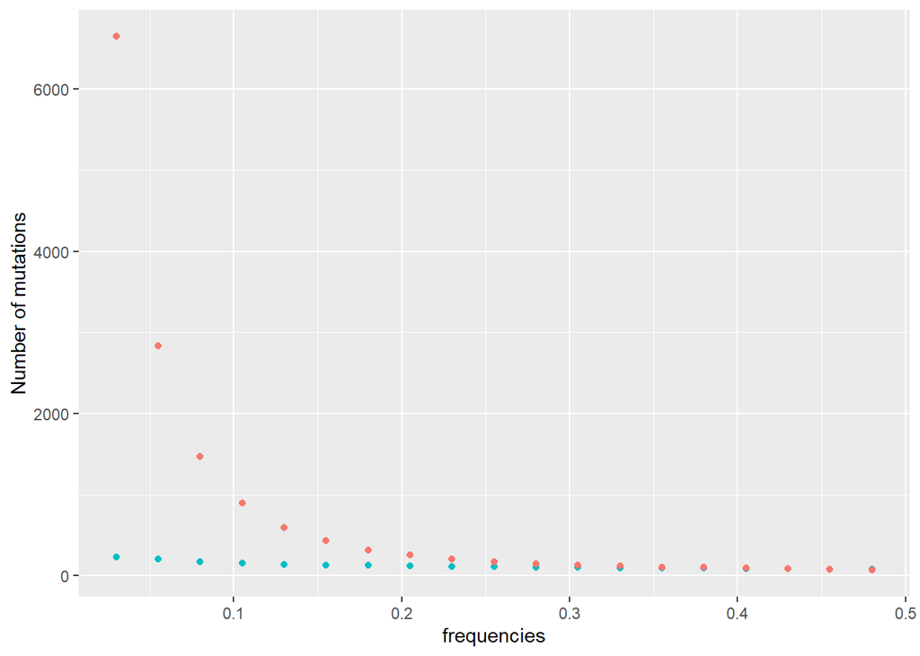

```r
plot_mut_freq(month = "jan")
```

February:

```
##    identified not_id frequencies
## 1         206   6073       0.030
## 2         164   2473       0.055
## 3         137   1251       0.080
## 4         110    773       0.105
## 5          98    515       0.130
## 6          88    359       0.155
## 7          74    246       0.180
## 8          68    179       0.205
## 9          56    123       0.230
## 10         54     88       0.255
## 11         50     65       0.280
## 12         45     58       0.305
## 13         41     45       0.330
## 14         39     37       0.355
## 15         37     33       0.380
## 16         37     30       0.405
## 17         37     28       0.430
## 18         37     27       0.455
## 19         35     25       0.480
```

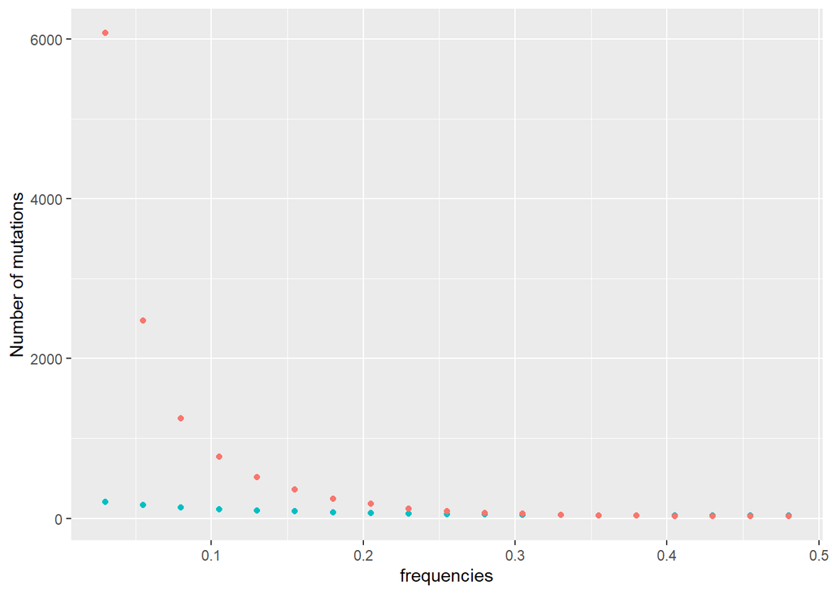

```r
plot_mut_freq(month = "fev")
```

March:

```
##    identified not_id frequencies
## 1         211   6555       0.030
## 2         175   2874       0.055
## 3         145   1576       0.080
## 4         129   1045       0.105
## 5         118    735       0.130
## 6         108    555       0.155
## 7          99    420       0.180
## 8          87    313       0.205
## 9          84    259       0.230
## 10         82    210       0.255
## 11         78    173       0.280
## 12         75    153       0.305
## 13         74    137       0.330
## 14         72    125       0.355
## 15         69    116       0.380
## 16         66    102       0.405
## 17         62     93       0.430
## 18         57     82       0.455
## 19         53     76       0.480
```

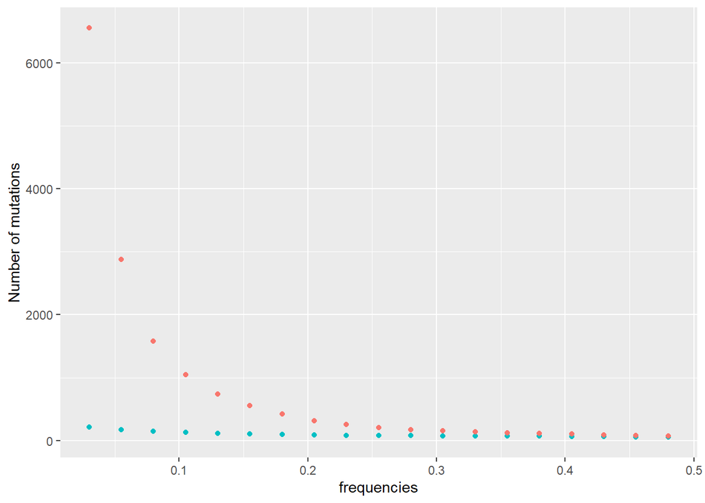

```r
plot_mut_freq(month = "mar")
```